# dvs_Project 1_Test a Perceptual Phenomenon-Copy3

1. **What is our independent variable? What is our dependent variable?**

   Independent Variable: The condition that the name of the color matches with the ink color  
   Dependent Variable: Time taken to name the ink color.
2. **What is an appropriate set of hypotheses for this task? What kind of statistical test do you expect to perform? Justify your choices**

   Our aim is to find out Is there any time difference, if the experiment is conducted with and without congruency condition.

   A two-sided paired student T-test can be used in this case.

   Null hypothesis H0 : µC - µI = 0 (No time difference)  
   Alternative hypothesis H1 : µC - µI != 0 (There is a difference)  
   where µC = congruent population mean and μI = Incongruent population means.

   t Test is used, because
   1. We have less than 30 samples.
   2. We don’t know the population's standard deviation.

```python
#3.Report some descriptive statistics regarding this dataset. Include at least one measure of central tendency and at least one measure of variability

import pandas as pd
import numpy as np
import matplotlib.pyplot as plt
import stat as st
from scipy.stats import probplot, ttest_1samp
from scipy import stats
import seaborn as sns

data = pd.read_csv('stroopdata.csv')

cngrnt = data['Congruent']
incngrnt = data['Incongruent']

data.describe()
```

|  | Congruent | Incongruent |
| --- | --- | --- |
| count | 24.000000 | 24.000000 |
| mean | 14.051125 | 22.015917 |
| std | 3.559358 | 4.797057 |
| min | 8.630000 | 15.687000 |
| 25% | 11.895250 | 18.716750 |
| 50% | 14.356500 | 21.017500 |
| 75% | 16.200750 | 24.051500 |
| max | 22.328000 | 35.255000 |

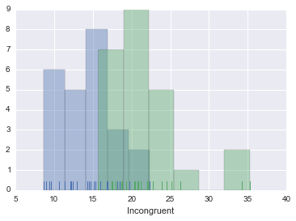

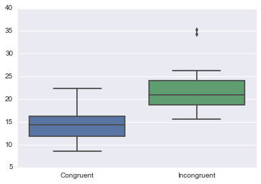

```python
#4.Provide one or two visualizations that show the distribution of the sample data. Write one or two sentences noting what you observe about the plot or plots.

%matplotlib inline

#histogram
sns.distplot(cngrnt,kde=False, rug=True)
sns.distplot(incngrnt,kde=False, rug=True)
sns.plt.show()

#boxplot
sns.boxplot(data=data);
sns.plt.show()
```

The Overlapping data can be seen in the histogram  
The boxplot shows the outliers, also the task time looks higher for Incongruent task

```python
#Now, perform the statistical test and report your results. What is your confidence level and your critical statistic value? Do you reject the null hypothesis or fail to reject it? Come to a conclusion in terms of the experiment task. Did the results match up with your expectations?
#MyCongruent: 11.374
#MyIncongruent: 33.221

cngrnt = data['Congruent']
incngrnt = data['Incongruent']
#diff = incngrnt - cngrnt
diff =  cngrnt - incngrnt

d_bar = np.mean(diff)
sd = np.std(diff)
n = np.count_nonzero(cngrnt)
SE_d = sd/np.sqrt(n)

t = d_bar/SE_d
DF = n-1
p = 2*stdtr(DF, -np.abs(t))
print 'Degree of Freedom = ',DF
print 't = ',t
print 'p = ',p
```

```
Degree of Freedom =  23
t =  -8.19321500097
p =  2.84117972476e-08
```

p value is less than alpha, 0.05.  
So reject Null Hypothesis.  
So, the difference in time between congruant and incongruence task is significant  
The result is maching with the initial expectation

**What do you think is responsible for the effects observed? Can you think of an alternative or similar task that would result in a similar effect?**  
According to http://www.rit.edu/cla/gssp400/sbackground.html ,Stroop effect appears to tap into essential operations of cognition, thereby offering clues to fundamental cognitive processes.  
Warped Words is another example (found from Web)

**References**

- https://en.wikipedia.org/wiki/Stroop_effect
- http://www.rit.edu/cla/gssp400/sbackground.html
- http://stanford.edu/~mwaskom/software/seaborn/tutorial.html
- http://blog.minitab.com/blog/adventures-in-statistics/understanding-hypothesis-tests%3A-why-we-need-to-use-hypothesis-tests-in-statistics